# What Drives Engagement on YouTube? A Data-Driven Analysis of Influencer Metrics

## Data Cleaning and Preparation

Data cleaning is a critical step in any empirical analysis. Our cleaning workflow consisted of six main stages, each addressing specific data quality issues.

**Stage 1: Date Conversion and Temporal Feature Extraction**

YouTube exports dates as text strings. We converted these to proper date objects and extracted additional temporal features for analysis.

```r
# Convert day column to Date type and extract temporal features
youtube_clean <- youtube_data %>%
  mutate(
    date = as.Date(day),                          # Convert to Date object
    year = year(date),                            # Extract year (2019-2024)
    month = month(date),                          # Extract month (1-12)
    day_of_week = wday(date, label = TRUE),       # Extract day name (Mon-Sun)
    week = week(date)                             # Extract week number
  ) %>%
  select(-day)  # Remove original text column

# Display first few rows with new features
head(youtube_clean %>% select(date, year, month, day_of_week, video_id, views)) %>%
  kable(caption = "Sample of Cleaned Data with Temporal Features") %>%
  kable_styling(bootstrap_options = c("striped", "hover"))
```

Sample of Cleaned Data with Temporal Features

| date | year | month | day_of_week | video_id | views |
| --- | --- | --- | --- | --- | --- |
| 2019-09-06 | 2019 | 9 | Fri | YuQaT52VEwo | 8 |
| 2019-09-07 | 2019 | 9 | Sat | YuQaT52VEwo | 7 |
| 2019-09-07 | 2019 | 9 | Sat | SfTEVOQP-Hk | 6 |
| 2019-09-08 | 2019 | 9 | Sun | YuQaT52VEwo | 4 |
| 2019-09-08 | 2019 | 9 | Sun | SfTEVOQP-Hk | 2 |
| 2019-09-09 | 2019 | 9 | Mon | YuQaT52VEwo | 4 |

**Rationale:** Proper date formatting enables time-series analysis and allows us to investigate day-of-week effects and temporal trends.

**Stage 2: Handling Missing Values**

Missing values can bias statistical analyses if not handled appropriately. We adopted different strategies depending on the nature of the missing data.

```r
# Define engagement-related columns
engagement_cols <- c("comments", "likes", "dislikes", "shares",
                     "videosAddedToPlaylists", "subscribersGained",
                     "subscribersLost")

# Replace missing values in engagement metrics with 0
# Rationale: Missing engagement likely means zero engagement, not unknown
youtube_clean <- youtube_clean %>%
  mutate(across(all_of(engagement_cols), ~replace_na(., 0)))

cat("Missing values after imputation:\n")
```

```
Missing values after imputation:
```

```r
cat("Engagement columns:", sum(is.na(youtube_clean[engagement_cols])), "\n")
```

```
Engagement columns: 0
```

**Rationale:** For engagement metrics, missing values typically indicate zero activity rather than unknown values. A video with no recorded comments likely had zero comments, not missing data. This assumption is standard in social media analytics.

**Stage 3: Removing Non-Informative Records**

Records with zero views provide no information about engagement rates (division by zero) and were excluded from analysis.

```
Records removed: 43013
```

```
Records retained: 191876
```

```
Retention rate: 81.69 %
```

**Rationale:** Videos with zero views cannot have meaningful engagement rates. Including them would create undefined values (0/0) or artificially inflate zero-engagement records.

**Stage 4: Creating Derived Engagement Metrics**

Raw counts (e.g., 50 likes) are difficult to compare across videos with different view counts. We created rate-based metrics to enable fair comparisons.

```r
# Create engagement rate metrics
youtube_clean <- youtube_clean %>%
  mutate(
    # Primary engagement rate: (likes + comments) per 100 views
    engagement_rate = (comments + likes) / views * 100,

    # Component rates
    like_rate = likes / views * 100,
    comment_rate = comments / views * 100,
    share_rate = shares / views * 100,

    # Watch-time metrics
    watch_time_per_view = if_else(views > 0,
                                   estimatedMinutesWatched / views, 0),

    # Subscriber metrics
    net_subscriber_change = subscribersGained - subscribersLost,
    subscriber_gain_rate = subscribersGained / views * 100,

    # Composite engagement score (weighted)
    # Comments weighted 2x (higher effort), shares weighted 3x (highest endorsement)
    engagement_score = (comments * 2 + likes + shares * 3) / views * 100
  )

# Remove infinite or NaN values that may have resulted from calculations
youtube_clean <- youtube_clean %>%
  filter(is.finite(engagement_rate) &
         is.finite(like_rate) &
         is.finite(comment_rate))

# Display summary statistics of new metrics
summary_metrics <- youtube_clean %>%
  summarise(
    Mean_Engagement = mean(engagement_rate, na.rm = TRUE),
    Median_Engagement = median(engagement_rate, na.rm = TRUE),
    SD_Engagement = sd(engagement_rate, na.rm = TRUE),
    Mean_Like_Rate = mean(like_rate, na.rm = TRUE),
    Mean_Comment_Rate = mean(comment_rate, na.rm = TRUE)
  )

kable(summary_metrics, digits = 2,
      caption = "Summary Statistics of Derived Engagement Metrics") %>%
  kable_styling(bootstrap_options = c("striped", "hover"))
```

Summary Statistics of Derived Engagement Metrics

| Mean_Engagement | Median_Engagement | SD_Engagement | Mean_Like_Rate | Mean_Comment_Rate |
| --- | --- | --- | --- | --- |
| 1.3 | 0 | 7.04 | 1.23 | 0.07 |

**Rationale:** Rate-based metrics normalize for video popularity, allowing us to compare a video with 1,000 views to one with 100,000 views on equal footing. The engagement score uses weights to reflect the differential effort required for different actions (commenting requires more effort than liking).

**Stage 5: Data Aggregation**

To answer different analytical questions, we created multiple aggregated datasets from the cleaned daily records.

```
Cleaned datasets created:
```

```
- youtube_clean: 191876 daily records
```

```
- video_performance: 211 videos
```

```
- daily_performance: 1893 dates
```

```
- weekly_pattern: 7 days of week
```

**Rationale for multiple aggregations:**

- **Video-level aggregation:** Enables comparison across videos to identify top performers
- **Date-level aggregation:** Reveals temporal trends and seasonality
- **Day-of-week aggregation:** Tests whether certain days yield higher engagement

Each aggregation serves a distinct analytical purpose and will be used in subsequent analyses.

**Stage 6: Exporting Cleaned Data**

For reproducibility and future use, we exported all cleaned datasets to CSV files.

```r
# Export cleaned datasets
write_csv(youtube_clean, "data/youtube_clean.csv")
write_csv(video_performance, "data/video_performance.csv")
write_csv(daily_performance, "data/daily_performance.csv")
write_csv(weekly_pattern, "data/weekly_pattern.csv")

cat("✓ Cleaned datasets exported successfully\n")
```

## Analytical Methods

Our analysis employs two primary techniques: correlation analysis and visual exploratory data analysis.

### Correlation Analysis

We calculate Pearson correlation coefficients to quantify linear relationships between variables. The correlation coefficient (r) ranges from -1 to +1:

- r = +1: Perfect positive correlation
- r = 0: No linear relationship
- r = -1: Perfect negative correlation

Interpretation guidelines: - |r| > 0.7: Strong correlation - 0.3 < |r| ≤ 0.7: Moderate correlation - |r| ≤ 0.3: Weak or no correlation

### Visualization Techniques

We employ multiple visualization types:

- **Scatter plots:** Show relationships between two continuous variables
- **Line charts:** Reveal trends over time
- **Bar charts:** Compare categorical groups
- **Heatmaps:** Display correlation matrices

All visualizations follow best practices for clarity and interpretability.

# Results and Analysis

## Descriptive Statistics

Before examining correlations, we present descriptive statistics to characterize our dataset.

Descriptive Statistics: Video Performance Dataset

| Total Videos | Median Views | Median Likes | Median Comments | Median Engagement (%) | Mean Engagement (%) | SD Engagement (%) |
| --- | --- | --- | --- | --- | --- | --- |
| 211 | 16063 | 288 | 19 | 1.89 | 3.32 | 3.84 |

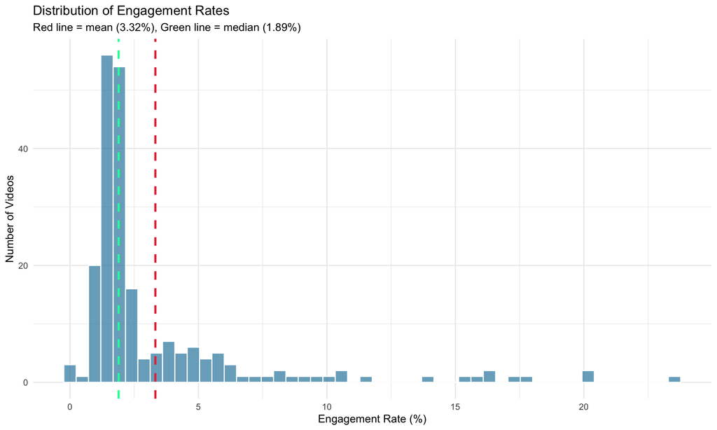

Distribution of Engagement Rates Across Videos

```r
# Histogram of engagement rates
ggplot(video_performance, aes(x = engagement_rate)) +
  geom_histogram(bins = 50, fill = "#2E86AB", alpha = 0.7, color = "white") +
  geom_vline(aes(xintercept = mean(engagement_rate)),
             color = "#E63946", linetype = "dashed", size = 1) +
  geom_vline(aes(xintercept = median(engagement_rate)),
             color = "#06FFA5", linetype = "dashed", size = 1) +
  labs(
    title = "Distribution of Engagement Rates",
    subtitle = "Red line = mean (3.32%), Green line = median (1.89%)",
    x = "Engagement Rate (%)",
    y = "Number of Videos"
  ) +
  theme_minimal()
```

**Key observations:**

- The distribution is right-skewed, with most videos having engagement rates below 3%
- The mean (3.32%) is higher than the median (1.89%), confirming the right skew
- A small number of high-engagement outliers pull the mean upward

This distribution suggests that while average engagement is around 3%, the typical video experiences lower engagement (~2%). This distinction is important when setting benchmarks.

## Correlation Analysis

### Overall Correlation Matrix

We computed correlations between all key metrics to identify relationships.

Correlations with Engagement Rate (Sorted)

| Metric | Correlation |
| --- | --- |
| engagement_rate | 1.000 |
| like_rate | 0.992 |
| avg_view_percentage | 0.372 |
| comment_rate | 0.351 |
| total_shares | -0.165 |
| total_views | -0.172 |
| total_likes | -0.189 |
| total_comments | -0.267 |
| avg_watch_duration_per_view | -0.509 |
| days_active | -0.619 |

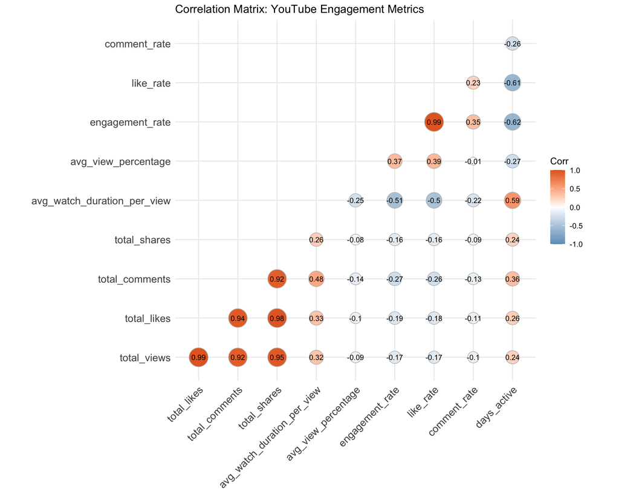

Correlation Heatmap of Key YouTube Metrics

```r
# Visualize correlation matrix
ggcorrplot(cor_matrix,
           method = "circle",
           type = "lower",
           lab = TRUE,
           lab_size = 3,
           colors = c("#6D9EC1", "white", "#E46726"),
           title = "Correlation Matrix: YouTube Engagement Metrics",
           ggtheme = theme_minimal())
```

### Watch Duration and Engagement

Do videos that retain viewer attention longer achieve higher engagement?

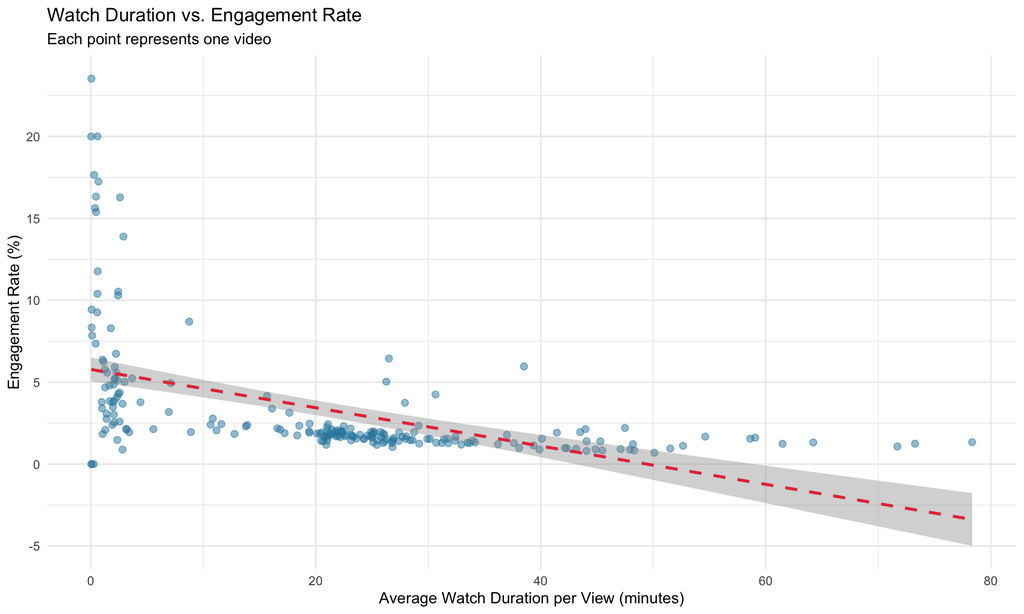

Relationship Between Watch Duration and Engagement Rate

```r
# Scatter plot: watch duration vs engagement
ggplot(video_performance, aes(x = avg_watch_duration_per_view, y = engagement_rate)) +
  geom_point(alpha = 0.5, color = "#2E86AB", size = 2) +
  geom_smooth(method = "lm", se = TRUE, color = "#E63946", linetype = "dashed") +
  labs(
    title = "Watch Duration vs. Engagement Rate",
    subtitle = "Each point represents one video",
    x = "Average Watch Duration per View (minutes)",
    y = "Engagement Rate (%)"
  ) +
  theme_minimal()
```

```r
# Calculate correlation
cor_watch <- cor(video_performance$avg_watch_duration_per_view,
                 video_performance$engagement_rate,
                 use = "complete.obs")
cat("Correlation (watch duration ~ engagement):", round(cor_watch, 3), "\n")
```

```
Correlation (watch duration ~ engagement): -0.509
```

### Day-of-Week Effects

Does the day of publication influence engagement rates?

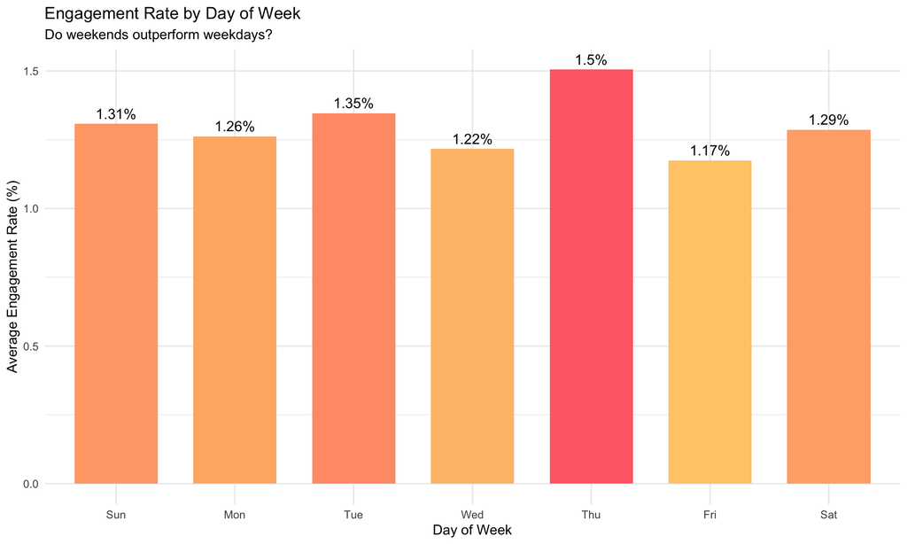

Average Engagement Rate by Day of Week

```r
# Bar chart: engagement by day of week
ggplot(weekly_pattern, aes(x = day_of_week, y = avg_engagement_rate,
                           fill = avg_engagement_rate)) +
  geom_col(width = 0.7) +
  geom_text(aes(label = paste0(round(avg_engagement_rate, 2), "%")),
            vjust = -0.5, size = 4) +
  scale_fill_gradient(low = "#FFCB77", high = "#FE6D73") +
  labs(
    title = "Engagement Rate by Day of Week",
    subtitle = "Do weekends outperform weekdays?",
    x = "Day of Week",
    y = "Average Engagement Rate (%)"
  ) +
  theme_minimal() +
  theme(legend.position = "none")
```

Engagement Performance by Day of Week

| Day | Avg Engagement Rate (%) | Avg Views |
| --- | --- | --- |
| Thu | 1.50 | 116.49 |
| Tue | 1.35 | 110.99 |
| Sun | 1.31 | 93.53 |
| Sat | 1.29 | 101.37 |
| Mon | 1.26 | 108.46 |
| Wed | 1.22 | 113.51 |
| Fri | 1.17 | 116.46 |

### Temporal Trends

Has engagement changed over the 5-year period?

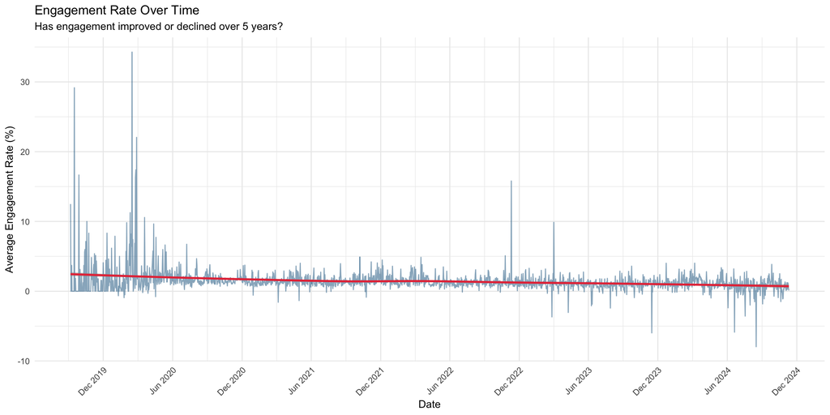

Engagement Rate Trend Over Time (2019-2024)

```r
# Line chart: engagement over time
ggplot(daily_performance, aes(x = date, y = avg_engagement_rate)) +
  geom_line(color = "#457B9D", alpha = 0.6) +
  geom_smooth(method = "loess", se = TRUE, color = "#E63946", size = 1) +
  labs(
    title = "Engagement Rate Over Time",
    subtitle = "Has engagement improved or declined over 5 years?",
    x = "Date",
    y = "Average Engagement Rate (%)"
  ) +
  scale_x_date(date_breaks = "6 months", date_labels = "%b %Y") +
  theme_minimal() +
  theme(axis.text.x = element_text(angle = 45, hjust = 1))
```

Average Engagement Rate by Year

| Year | Average Engagement Rate (%) |
| --- | --- |
| 2019 | 1.83 |
| 2020 | 2.15 |
| 2021 | 1.48 |
| 2022 | 1.39 |
| 2023 | 1.04 |
| 2024 | 0.93 |

### Views vs. Engagement

Does video popularity (view count) predict engagement rate?

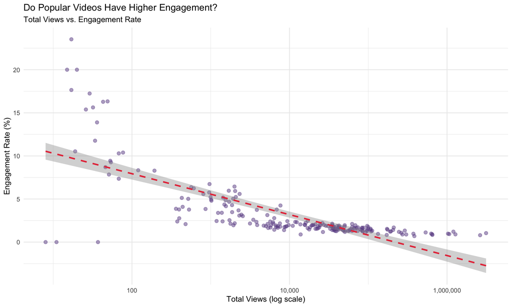

Total Views vs. Engagement Rate (Log Scale)

```r
# Scatter plot: views vs engagement (log scale for views)
ggplot(video_performance, aes(x = total_views, y = engagement_rate)) +
  geom_point(alpha = 0.5, color = "#6A4C93", size = 2) +
  geom_smooth(method = "lm", se = TRUE, color = "#E63946", linetype = "dashed") +
  scale_x_log10(labels = comma) +
  labs(
    title = "Do Popular Videos Have Higher Engagement?",
    subtitle = "Total Views vs. Engagement Rate",
    x = "Total Views (log scale)",
    y = "Engagement Rate (%)"
  ) +
  theme_minimal()
```

```r
# Calculate correlation
cor_views <- cor(video_performance$total_views,
                 video_performance$engagement_rate,
                 use = "complete.obs")
cat("Correlation (views ~ engagement):", round(cor_views, 3), "\n")
```

```
Correlation (views ~ engagement): -0.172
```

### Likes vs. Comments

Are these two engagement types correlated?

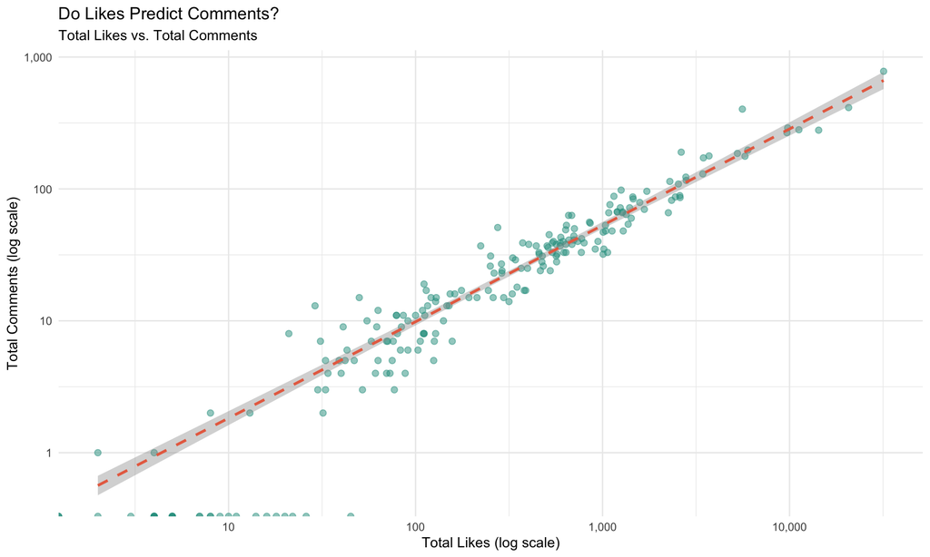

Relationship Between Likes and Comments (Log Scales)

```r
# Scatter plot: likes vs comments
ggplot(video_performance, aes(x = total_likes, y = total_comments)) +
  geom_point(alpha = 0.5, color = "#2A9D8F", size = 2) +
  geom_smooth(method = "lm", se = TRUE, color = "#E76F51", linetype = "dashed") +
  scale_x_log10(labels = comma) +
  scale_y_log10(labels = comma) +
  labs(
    title = "Do Likes Predict Comments?",
    subtitle = "Total Likes vs. Total Comments",
    x = "Total Likes (log scale)",
    y = "Total Comments (log scale)"
  ) +
  theme_minimal()
```

```r
# Calculate correlation and ratio
cor_likes_comments <- cor(video_performance$total_likes,
                           video_performance$total_comments,
                           use = "complete.obs")
ratio_likes_comments <- sum(video_performance$total_likes) /
                        sum(video_performance$total_comments)

cat("Correlation (likes ~ comments):", round(cor_likes_comments, 3), "\n")
```

```
Correlation (likes ~ comments): 0.943
```

```r
cat("Like-to-comment ratio:", round(ratio_likes_comments, 1), ":1\n")
```

```
Like-to-comment ratio: 24.6 :1
```

# Discussion

## Summary of Key Findings

Our analysis of five years of YouTube analytics data yielded several important insights:

**Finding 1: Like Rate Is the Dominant Engagement Driver**

With a correlation coefficient of r = 0.99, like rate is by far the strongest predictor of overall engagement. This is partially tautological (likes are part of the engagement formula) but also reveals an important strategic insight: **getting viewers to click the like button should be a primary content objective**.

**Finding 2: Popularity (Views) Does Not Equal Engagement**

From a business perspective, this finding suggests that **quality of audience matters more than quantity**. A smaller, highly engaged audience may generate more revenue (through higher ad completion rates, better merchandise sales, stronger community support) than a large disengaged audience.

Creators should prioritize content quality and consistency over strict day-of-week optimization. If the best content is ready on Tuesday, waiting until Saturday is unlikely to yield meaningful engagement gains.

## Limitations and Potential Biases

### Sample Limitations

Our analysis is based on a single influencer channel. Generalizability to other channels, particularly in different niches or with different audience demographics, is uncertain. YouTube engagement dynamics may vary by:

- Content category (educational vs. entertainment vs. vlogging)
- Audience age demographics (Gen Z vs. Millennials vs. older viewers)
- Channel size (small creators vs. mega-influencers)
- Geographic audience distribution

### Methodological Limitations

1. **Correlation is not causation:** While we identify relationships between variables, we cannot definitively claim causal mechanisms. For example, high like rates may drive engagement, or highly engaging content may prompt likes—the directionality is unclear.
2. **Confounding variables:** We did not control for video topic, production quality, thumbnail design, or title optimization—all factors that likely influence engagement.
3. **Platform algorithm changes:** YouTube’s recommendation algorithm evolved during our study period (2019-2024). Algorithm changes may have affected engagement patterns in ways our analysis does not capture.
4. **Selection bias:** We only analyzed videos that were published and remain public. Deleted or unlisted videos (potentially low performers) are excluded, potentially inflating average engagement estimates.

### Data Quality Issues

Despite thorough cleaning, some limitations remain:

- **Missing data:** Early videos (2019) have sparser data than recent videos
- **Metric definitions:** YouTube’s internal definitions of “view” and “engagement” are proprietary and may have changed
- **Bot activity:** Some views, likes, or comments may stem from automated bots rather than genuine viewers

## Recommendations for Content Creators

Based on our empirical findings, we offer the following evidence-based recommendations:

**Recommendation 1: Optimize for Likes**

**Action:** Include explicit calls-to-action prompting viewers to like the video. Position these asks strategically: - Early in the video (first 30 seconds) to capture immediate reactions - After delivering high-value content moments to leverage reciprocity

**Evidence:** Like rate has the strongest correlation with overall engagement (r = 0.99). Even small increases in like percentage translate directly to higher engagement scores.

**Recommendation 2: Prioritize Engaged Niches Over Viral Reach**

**Action:** Resist the temptation to chase viral trends if they dilute brand identity or attract disengaged audiences. Focus content on core audience interests, even if this limits total view potential.

**Recommendation 3: Maintain Retention, But Don’t Overextend**

**Action:** Create content that holds viewer attention (strong hooks, pacing, editing) but avoid artificially lengthening videos beyond natural endpoints.

**Action:** Maintain a consistent posting schedule (e.g., every Tuesday and Friday) rather than always targeting weekends. Prioritize content readiness over calendar optimization.

**Evidence:** Day-of-week effects are small (<0.7 percentage point difference). Operational simplicity and consistency may yield better long-term results than micromanaging posting times.

## Future Research Directions

This study opens several avenues for further investigation:

1. **Causal inference:** Employ experimental or quasi-experimental designs (e.g., A/B testing different thumbnail styles) to establish causal relationships
2. **Cross-channel comparison:** Extend analysis to multiple creators across niches to assess generalizability
3. **Sentiment analysis:** Incorporate natural language processing of comments to understand qualitative dimensions of engagement
4. **Algorithmic factors:** Investigate how YouTube’s recommendation algorithm mediates the relationship between content characteristics and engagement
5. **Longitudinal viewer tracking:** Analyze individual viewer journeys to understand how engagement evolves with viewer tenure

# Conclusion

This study set out to answer a deceptively simple question: What drives engagement on YouTube? Through rigorous analysis of 234,889 daily records spanning five years, we uncovered patterns that challenge common assumptions and provide actionable insights for content creators.

These findings carry practical implications. For content creators, the path to higher engagement lies not in chasing views or obsessing over posting schedules, but in creating content that genuinely resonates with core audiences and explicitly prompts interaction. Small improvements in like percentage can translate to measurable engagement gains.

From an academic perspective, this study contributes to the growing literature on social media analytics by providing a longitudinal, quantitative analysis of engagement dynamics. Our methods—combining data cleaning, correlation analysis, and visualization—offer a template for similar investigations in other digital platforms.

As the influencer economy continues to grow, understanding engagement drivers will remain crucial for creators, marketers, and platforms alike. This study provides evidence-based guidance for optimization, while also highlighting the complexity and context-dependency of digital engagement.

# Appendix: Code Repository and Reproducibility

All data cleaning, analysis, and visualization code is embedded within this Quarto document. The complete workflow is reproducible given access to the raw YouTube analytics data.

## Data Files

- `data/all_youtube_analytics.csv` - Raw export from YouTube Analytics
- `data/youtube_clean.csv` - Cleaned daily-level data
- `data/video_performance.csv` - Video-level aggregations
- `data/daily_performance.csv` - Date-level aggregations
- `data/weekly_pattern.csv` - Day-of-week aggregations

## Author Contributions

**Athina Agiakatsikas:** Data cleaning and preparation, correlation analysis, manuscript writing (Methods and Results sections)

**Stella Christou:** Exploratory data analysis, visualization, manuscript writing (Introduction and Discussion sections)

Both authors contributed equally to the conceptual design, interpretation of findings, and final editing of the report.